# Practical Machine Learning - Final Project

Nathan Weyer

10/17/2021

## Overview

This document is the final project for the [Practical Machine Learning](https://www.coursera.org/learn/practical-machine-learning) module. The objective of this project is to examine a dataset of movements as recorded by wearable recording devices and the determine which exersize was being preformed.

It should be noted that at the time of this writing, the codebook is no longer available for download.

## Assignment

Using devices such as Jawbone Up, Nike FuelBand, and Fitbit it is now possible to collect a large amount of data about personal activity relatively inexpensively. These type of devices are part of the quantified self movement – a group of enthusiasts who take measurements about themselves regularly to improve their health, to find patterns in their behavior, or because they are tech geeks. One thing that people regularly do is quantify how much of a particular activity they do, but they rarely quantify how well they do it. In this project, your goal will be to use data from accelerometers on the belt, forearm, arm, and dumbell of 6 participants. They were asked to perform barbell lifts correctly and incorrectly in 5 different ways. More information is available from the website here: http://groupware.les.inf.puc-rio.br/har (see the section on the Weight Lifting Exercise Dataset).

## Loading and Cleaning

### Libraries

```r
library(dplyr)
library(ggplot2)
library(caret)
library(rattle)
library(randomForestExplainer)
library(mgcv)
```

### Soure Data

```r
raw_train_data <- read.csv("pml-training.csv")
raw_test_data <- read.csv("pml-testing.csv")
set.seed(17)
```

### Initial Exploration

```r
dim(raw_test_data)
```

```
## [1]  20 160
```

```r
dim(raw_train_data)
```

```
## [1] 19622   160
```

### Partition and Factor the Data

```r
train_data <- raw_train_data
train_data$classe <- factor(train_data$classe)
train_rows <- createDataPartition(y=train_data$classe, p=0.7, list=FALSE)
train_data <- train_data[train_rows, ];
validation_data <- train_data[-train_rows, ]
```

### Remove Index, TimeStamps, Mosty NA, and near zero varience features.

```r
static_features <- c("X","raw_timestamp_part_1","raw_timestamp_part_2","cvtd_timestamp")
na_features <- names(raw_train_data)[sapply(raw_train_data, function(x) mean(is.na(x))) > 0.80]
near_zero_features <- names(raw_train_data)[nearZeroVar(raw_train_data)]
skip_features <- c(static_features,near_zero_features,na_features)
train_data <- train_data[ , -which(names(raw_test_data) %in% skip_features)]
validation_data <- validation_data[ , -which(names(raw_test_data) %in% skip_features)]
test_data <- raw_test_data[ , -which(names(raw_test_data) %in% skip_features)]

dim(train_data)
```

```
## [1] 13737    55
```

```r
dim(validation_data)
```

```
## [1] 4126   55
```

```r
dim(test_data)
```

```
## [1] 20 55
```

This leaves us with 55 features out of the original 160

## Models

First let us set up a common training parameter control, with 5 fold cross validation

```r
train_params <- trainControl(method = "cv", number = 5)
```

### Decision Tree

#### Training

```r
tree_train <- train(classe ~ .,data=train_data,method='rpart',trControl=train_params)
```

[figure not shown]

```r
fancyRpartPlot(tree_train$finalModel)
```

#### Prediction

```r
tree_predict <- predict(tree_train,validation_data)
tree_cm <- confusionMatrix(tree_predict, validation_data$classe)
print(tree_cm)
```

```
## Confusion Matrix and Statistics
##
##           Reference
## Prediction    A    B    C    D    E
##          A 1052  325  356  322  107
##          B   20  257   23  133   95
##          C   96  205  334  259  207
##          D    0    0    0    0    0
##          E    1    0    0    0  334
##
## Overall Statistics
##
##                Accuracy : 0.4792
##                  95% CI : (0.4638, 0.4945)
##     No Information Rate : 0.2833
##     P-Value [Acc > NIR] : < 2.2e-16
##
##                   Kappa : 0.3204
##
##  Mcnemar's Test P-Value : NA
##
## Statistics by Class:
##
##                      Class: A Class: B Class: C Class: D Class: E
## Sensitivity            0.8999  0.32656  0.46844    0.000  0.44953
## Specificity            0.6246  0.91884  0.77527    1.000  0.99970
## Pos Pred Value         0.4866  0.48674  0.30336      NaN  0.99701
## Neg Pred Value         0.9404  0.85270  0.87471    0.827  0.89211
## Prevalence             0.2833  0.19074  0.17281    0.173  0.18008
## Detection Rate         0.2550  0.06229  0.08095    0.000  0.08095
## Detection Prevalence   0.5240  0.12797  0.26684    0.000  0.08119
## Balanced Accuracy      0.7623  0.62270  0.62186    0.500  0.72462
```

### Random Forest

#### Training

```r
forest_train <- train(classe ~ .,data=train_data,method='rf',trControl=train_params)
min_depth_frame <- min_depth_distribution(forest_train$finalModel)
```

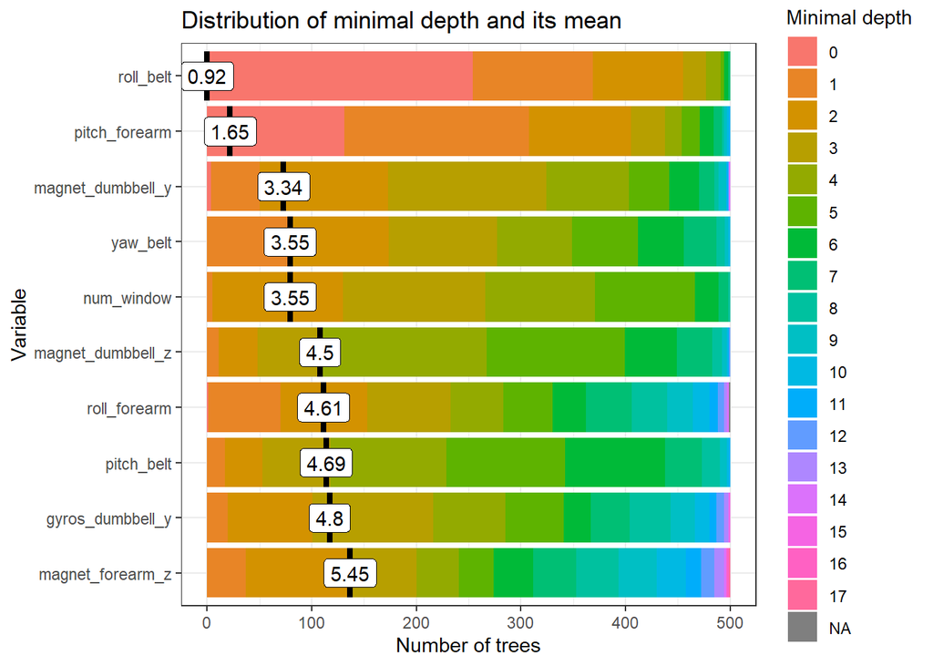

```r
plot_min_depth_distribution(min_depth_frame)
```

#### Prediction

```r
forest_predict <- predict(forest_train,validation_data)
forest_cm <- confusionMatrix(forest_predict, validation_data$classe)
print(forest_cm)
```

```
## Confusion Matrix and Statistics
##
##           Reference
## Prediction    A    B    C    D    E
##          A 1169    0    0    0    0
##          B    0  787    0    0    0
##          C    0    0  713    0    0
##          D    0    0    0  714    0
##          E    0    0    0    0  743
##
## Overall Statistics
##
##                Accuracy : 1
##                  95% CI : (0.9991, 1)
##     No Information Rate : 0.2833
##     P-Value [Acc > NIR] : < 2.2e-16
##
##                   Kappa : 1
##
##  Mcnemar's Test P-Value : NA
##
## Statistics by Class:
##
##                      Class: A Class: B Class: C Class: D Class: E
## Sensitivity            1.0000   1.0000   1.0000    1.000   1.0000
## Specificity            1.0000   1.0000   1.0000    1.000   1.0000
## Pos Pred Value         1.0000   1.0000   1.0000    1.000   1.0000
## Neg Pred Value         1.0000   1.0000   1.0000    1.000   1.0000
## Prevalence             0.2833   0.1907   0.1728    0.173   0.1801
## Detection Rate         0.2833   0.1907   0.1728    0.173   0.1801
## Detection Prevalence   0.2833   0.1907   0.1728    0.173   0.1801
## Balanced Accuracy      1.0000   1.0000   1.0000    1.000   1.0000
```

### Gradient Boost

#### Training

```r
gbm_train <- train(classe ~ .,data=train_data,method='gbm',trControl=train_params,verbose = FALSE)
```

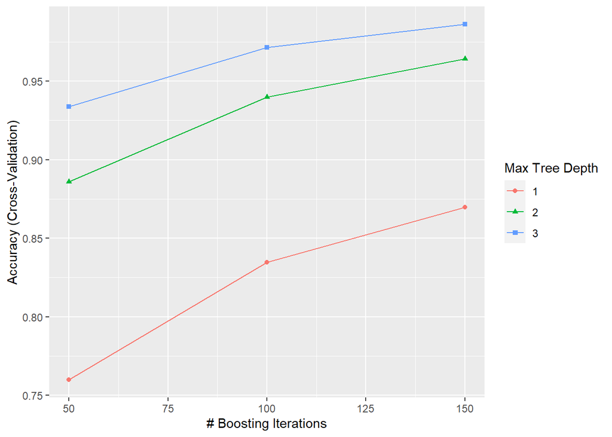

```r
ggplot(gbm_train)
```

#### Prediction

```r
gbm_predict <- predict(gbm_train,validation_data)
gbm_cm <- confusionMatrix(gbm_predict, validation_data$classe)
print(gbm_cm)
```

```
## Confusion Matrix and Statistics
##
##           Reference
## Prediction    A    B    C    D    E
##          A 1169    3    0    0    0
##          B    0  782    3    3    1
##          C    0    2  710    4    1
##          D    0    0    0  707    3
##          E    0    0    0    0  738
##
## Overall Statistics
##
##                Accuracy : 0.9952
##                  95% CI : (0.9925, 0.997)
##     No Information Rate : 0.2833
##     P-Value [Acc > NIR] : < 2.2e-16
##
##                   Kappa : 0.9939
##
##  Mcnemar's Test P-Value : NA
##
## Statistics by Class:
##
##                      Class: A Class: B Class: C Class: D Class: E
## Sensitivity            1.0000   0.9936   0.9958   0.9902   0.9933
## Specificity            0.9990   0.9979   0.9979   0.9991   1.0000
## Pos Pred Value         0.9974   0.9911   0.9902   0.9958   1.0000
## Neg Pred Value         1.0000   0.9985   0.9991   0.9980   0.9985
## Prevalence             0.2833   0.1907   0.1728   0.1730   0.1801
## Detection Rate         0.2833   0.1895   0.1721   0.1714   0.1789
## Detection Prevalence   0.2841   0.1912   0.1738   0.1721   0.1789
## Balanced Accuracy      0.9995   0.9958   0.9969   0.9947   0.9966
```

### Combined

```r
comb_df = data.frame(tree_predict,forest_predict,gbm_predict,classe=validation_data$classe)
comb_train = train(classe ~ .,data=comb_df,method="gam",trControl=train_params)
comb_predict = predict(comb_train,comb_df)
comb_cm <- confusionMatrix(comb_predict, validation_data$classe)
print(comb_cm)
```

```
## Confusion Matrix and Statistics
##
##           Reference
## Prediction    A    B    C    D    E
##          A 1169    0    0    0    0
##          B    0  787  713  714  743
##          C    0    0    0    0    0
##          D    0    0    0    0    0
##          E    0    0    0    0    0
##
## Overall Statistics
##
##                Accuracy : 0.4741
##                  95% CI : (0.4587, 0.4894)
##     No Information Rate : 0.2833
##     P-Value [Acc > NIR] : < 2.2e-16
##
##                   Kappa : 0.3283
##
##  Mcnemar's Test P-Value : NA
##
## Statistics by Class:
##
##                      Class: A Class: B Class: C Class: D Class: E
## Sensitivity            1.0000   1.0000   0.0000    0.000   0.0000
## Specificity            1.0000   0.3501   1.0000    1.000   1.0000
## Pos Pred Value         1.0000   0.2661      NaN      NaN      NaN
## Neg Pred Value         1.0000   1.0000   0.8272    0.827   0.8199
## Prevalence             0.2833   0.1907   0.1728    0.173   0.1801
## Detection Rate         0.2833   0.1907   0.0000    0.000   0.0000
## Detection Prevalence   0.2833   0.7167   0.0000    0.000   0.0000
## Balanced Accuracy      1.0000   0.6751   0.5000    0.500   0.5000
```

## Results

Random Forest seems to have behaved the best, with an accuracy of 1.0, which probably means it overfit even with the validation data.

Interestingly enough, the combination model preformed the worst, which might be worth investigating at a later point.

| Model | Accuracy | Kappa | Out of Sample Error |
| --- | --- | --- | --- |
| Decision Tree | 0.4791566 | 0.3203998 | 0.5208434 |
| Random Forest | 1 | 1 | 0 |
| Gradient Boost | 0.9951527 | 0.9938721 | 0.0048473 |
| Combined | 0.4740669 | 0.3283334 | 0.5259331 |

### Final Prediction

```r
test_predict <- predict(forest_train, raw_test_data)
print(test_predict)
```

```
##  [1] B A B A A E D B A A B C B A E E A B B B
## Levels: A B C D E
```